# beta coefficients plot

Yanelli Nunez

7/12/2019

-If I give you seed 3 I get a full range and if I give you seed 1 I get a single point. -Do group lasso with single element groupings and see if we can replicate lasso -what is the vector matrix structure that we suppose to use for grp lasso

Note: R is version: 3.6.1 glmnet and grpreg package are the new versions

### Data Import and Cleaning

First, load the dataset; clean up names as needed; and convert factors to, well, factors. Next we remove missing values and reorder predictors (environmental variables first, confounders second). In keeping with standard practice, we’ll ln-transform the environmental exposures and the outcome. This is the dataset we’ll use to illustrate variable selection methods.

```r
study_pop = read_csv("../Data/studypop.csv") %>%
  clean_names(case = c("old_janitor")) %>%
  mutate(bmi_cat3 = as.factor(bmi_cat3),
         edu_cat = as.factor(edu_cat),
         race_cat = as.factor(race_cat),
         male = as.factor(male))
data = study_pop %>%
  mutate_at(vars(contains("la")), log) %>%
  mutate(log_telomean = log(telomean)) %>%
  dplyr::select(log_telomean, lbx074la:lbx187la, lbxd03la:lbx194la, everything(), -seqn, -telomean) %>%
  na.omit(log_telomean)

# Create a matrix of predictors as x
x = model.matrix(log_telomean ~ ., data)[,-1]

# Extract outcome vector
y = data$log_telomean
```

# Lasso

### Lasso w/ CV

Some built-in functions will conduct a cross-validation analysis and identify the “best” tuning parameter. Optional arguments to `glmnet` can be useful – in particular, `weights` can be used in the context of the adaptive lasso and `penalty.factor` can separate penalized variables from confounders.

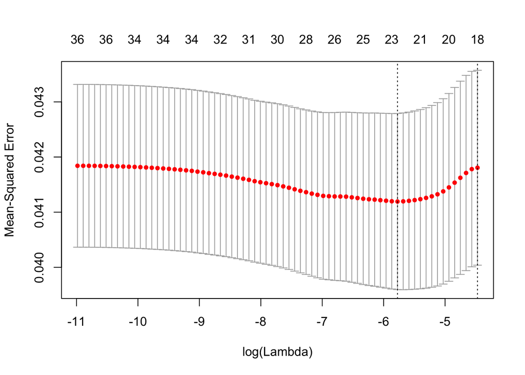

```r
set.seed(2)

is_penalized = c(rep(1, ncol(x[,1:18])), rep(0, ncol(x[,19:36])))

# Use cross-validation (CV) to find best lambda value
cv.lasso = cv.glmnet(x, y,
                     penalty.factor = is_penalized,
                     type.measure = "mse", alpha = 1)
plot(cv.lasso)
```

```r
best_lambda = cv.lasso$lambda.min
best_lambda
```

```
## [1] 0.003105342
```

### Looping seeds for lasso for coefficients plot

```r
fit_cv_lasso = function(seed) {
  set.seed(seed)
  cv.lasso = cv.glmnet(x, y,
                     penalty.factor = c(rep(1, ncol(x[,1:18])), rep(0, ncol(x[,19:36]))),
                     type.measure = "mse", alpha = 1)

  #Find the lambda that results in the smallest CV error
  best_lambda <- cv.lasso$lambda.min


  #Fit model with cross-validated lambda
  lasso.mod = glmnet(x, y,
                   penalty.factor = c(rep(1, ncol(x[,1:18])), rep(0, ncol(x[,19:36]))),
                   alpha = 1, lambda = best_lambda)

lasso.mod
}


extract_coefs = function(fit) {
 as.tibble(as.matrix(fit$beta), rownames = "variable") %>%
    rename(beta = s0)
}


repeat_cv_lasso =
  tibble(seed = 1:100) %>%
  mutate(
    fits = map(seed, ~fit_cv_lasso(seed = .x)),
    coefs = map(fits, extract_coefs)) %>%
  dplyr::select(-fits) %>%
  unnest() %>%
  rename(beta_lasso = "beta")
```

### Looping seeds for lasso for lambda plot

```r
fit_cv_lasso_2 = function(seed) {
  set.seed(seed)
  cv.lasso = cv.glmnet(x, y,
                     penalty.factor = c(rep(1, ncol(x[,1:18])), rep(0, ncol(x[,19:36]))),
                     type.measure = "mse", alpha = 1)


 loop_cvm    <- cv.lasso$cvm  # mean cross-validation error
  loop_cvsd   <- cv.lasso$cvsd #std error of CV error
  loop_lam    <- cv.lasso$lambda

  dat <- cbind(lam = loop_lam, cvm = loop_cvm, cvsd = loop_cvsd) %>%
    as_tibble() %>%
    mutate(upper = cvm + 1.96*cvsd,
         lower = cvm - 1.96*cvsd) %>%
    mutate(seed1 = seed)

}

repeat_cv_lasso_2 =
  tibble(seed = 1:100) %>%
  mutate(
    fits = map(seed, ~fit_cv_lasso_2(seed = .x))) %>%
  unnest() %>%
  mutate(seed = as.factor(seed))
```

# Lasso visualization

#### betas

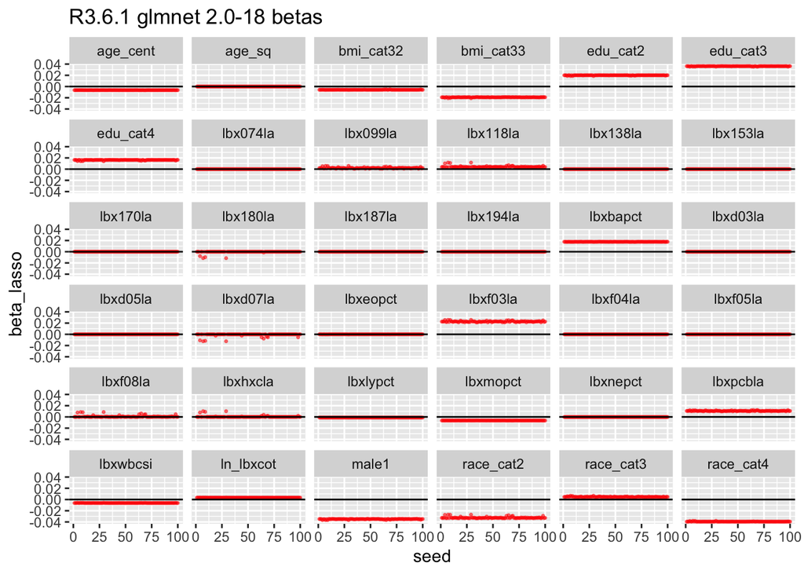

```r
repeat_cv_lasso  %>%
  ggplot() +
  geom_point(aes(x = seed, y = beta_lasso), color = 'red', size = 0.5, alpha = 0.5) +
  facet_wrap(~variable) +
  geom_hline(yintercept = 0) +
  ggtitle("R3.6.1 glmnet 2.0-18 betas")
```

# compiling data for final summary beta plot

```r
data_lasso <- repeat_cv_lasso %>%
  filter(!variable %in% c("bmi_cat32", "bmi_cat33", "edu_cat2", "edu_cat3", "edu_cat4", "race_cat2", "race_cat3", "race_cat4", "male1", "ln_lbxcot", "age_cent", "age_sq", "lbxwbcsi", "lbxlypct", "lbxlypct", "lbxmopct", "lbxmopct", "lbxnepct",
"lbxnepct", "lbxeopct", "lbxeopct", "lbxbapct", "lbxbapct")) %>%
  mutate(Group = ifelse(variable == "lbx118la", "mPFD",
                        ifelse(grepl("lbx1", variable), "Non-Dioxin-like PCBs",
                          ifelse(grepl("lbx0", variable), "Non-Dioxin-like PCBs",
                            ifelse(grepl("lbxp", variable), "Non-Ortho PCBs",
                              ifelse(grepl("lbxh", variable), "Non-Ortho PCBs", "mPFD")))))) %>%
  mutate(variable = as.factor(variable),
          chem = fct_recode(variable, "PCB 74" = "lbx074la",
                                "PCB 99" = "lbx099la",
                                "PCB 118" = "lbx118la",
                                "PCB 138" = "lbx138la",
                                "PCB 153" = "lbx153la",
                                "PCB 170" = "lbx170la",
                                "PCB 180" = "lbx180la",
                                "PCB 187" = "lbx187la",
                                "PCB 194" = "lbx194la",
                                "1,2,3,6,7,8-hxcdd" = "lbxd03la",
                                "1,2,3,4,6,7,8-hpcdd" = "lbxd05la",
                               "1,2,3,4,6,7,8,9-ocdd" =  "lbxd07la",
                               "2,3,4,7,8-pncdf" =  "lbxf03la",
                               "1,2,3,4,7,8-hxcdf" =  "lbxf04la",
                               "1,2,3,6,7,8-hxcdf" =  "lbxf05la",
                               "1,2,3,4,6,7,8-hxcdf" =  "lbxf08la",
                               "PCB 169" =  "lbxhxcla",
                                "PCB 126" = "lbxpcbla")) %>%
  dplyr::select(-variable) %>%
  group_by(chem) %>%
  mutate(mean = mean(beta_lasso),
            se = sd(beta_lasso)/sqrt(length(beta_lasso))) %>%
  dplyr::select(seed, Group, chem, beta_lasso, everything())

#counting non zero coefficients

counts <- data_lasso %>%
  filter(beta_lasso != 0) %>%
  group_by(chem) %>%
  summarise(number_nonzero = n())


summary_data_lasso <- full_join(data_lasso, counts, by = "chem") %>%
  mutate_if(is.numeric, ~replace(., is.na(.), 0))
```

```
## `mutate_if()` ignored the following grouping variables:
## Column `chem`
```

# final summary plot for lasso

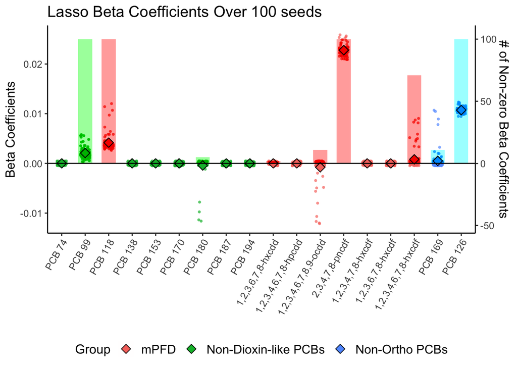

```r
summary_data_lasso %>%
  group_by(chem) %>%
  ggplot(aes(x = chem)) +
  geom_jitter(aes(y = beta_lasso, color = Group), shape=16, size = 1, alpha = 0.7,  position=position_jitter(height = 0.0005, width = .2)) +
  geom_point(aes(y = mean, fill = Group), shape = 23, size = 3, alpha = 1) +
 #geom_errorbar(aes(ymin = mean-se, ymax=mean+se), width=.1, position=position_dodge(0.05)) +
  stat_summary(aes(y = beta_lasso, fill = Group), fun.y = mean, geom ="point", shape=23, size=3, alpha = 0.4) +
  #geom_boxplot(aes(y = beta_lasso, color = Group), outlier.shape = NA, alpha = 0) +
  geom_col(aes(y = number_nonzero/4000, fill = Group), width = 0.6, position ="identity", alpha = 0.003) +
  scale_y_continuous(sec.axis = sec_axis(~.*4000, name = "# of Non-zero Beta Coefficients")) +
  theme_classic() +
  labs(y = "Beta Coefficients",
       x = element_blank(),
       title  = "Lasso Beta Coefficients Over 100 seeds") +
  theme(axis.text.x = element_text(angle = 60, hjust = 1, size = 9.5),
                      legend.position = "bottom",
                      legend.text = element_text(size = 12),
        axis.text.y = element_text(size = 9.5),
        text = element_text(size = 12.5)) +
  geom_hline(yintercept = 0)
```

### Lambda with Error Bars

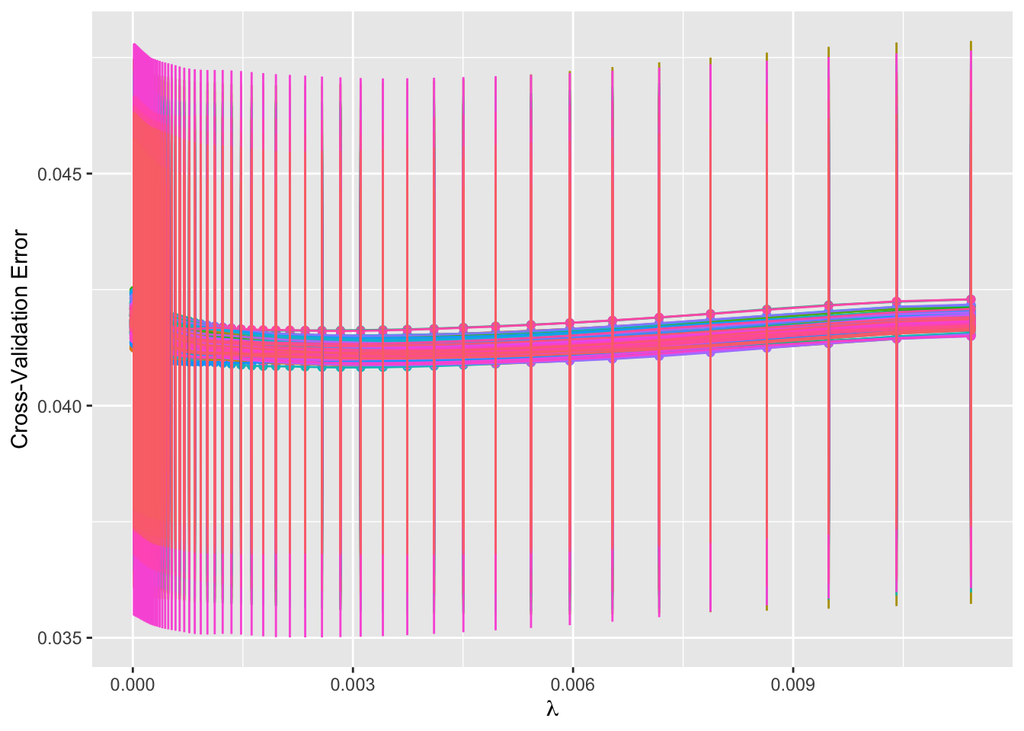

```r
repeat_cv_lasso_2 %>%
  ggplot(aes(x = lam, y = cvm, color = seed)) +
  geom_point() +
  geom_line() +
  geom_errorbar(aes(ymin = lower, ymax = upper)) +
  theme(legend.position = "none") +
  labs(x = expression(lambda), y = "Cross-Validation Error")
```

### Lambda without Error Bars

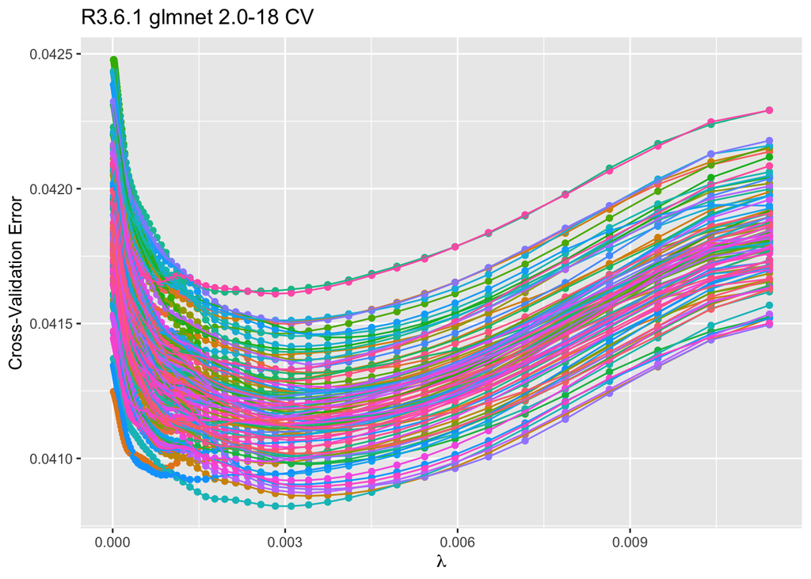

```r
repeat_cv_lasso_2 %>%
  ggplot(aes(x = lam, y = cvm, color = seed)) +
  geom_point() +
  geom_line() +
  theme(legend.position = "none") +
  labs(x = expression(lambda), y = "Cross-Validation Error") +
  ggtitle("R3.6.1 glmnet 2.0-18 CV")
```

### Selected lambda

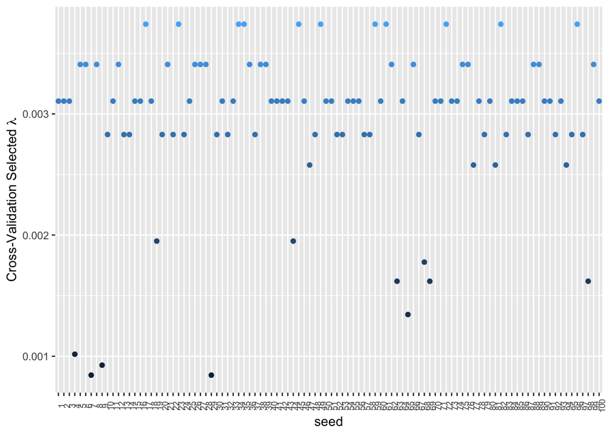

```r
min_cv <- repeat_cv_lasso_2 %>%
  group_by(seed) %>%
  filter(cvm == min(cvm))

min_cv %>%
  ggplot(aes(y = lam, x = seed)) +
  geom_point(aes(color = lam)) +
  theme(legend.position = "none",
        axis.text.x = element_text(angle = 90, size = 7)) +
  labs(x = "seed", y = expression("Cross-Validation Selected "*lambda))
```